# Prostate Cancer Case Study

Tomas Bencomo and Kyle W. Singleton

## Introduction

The presentation covered concepts we should be thinking about as we design studies and analyze survival data. This notebook will put these ideas into practice on real data using `R`.

Before reading this notebook, you should already know `R` basics like calling functions, loading data, manipulating dataframes, and fitting models. It’s also important to understand concepts like hypothesis testing, p-values, confidence intervals, linear regression, and hazard ratios. If you’re unsure of your `R` skills, Grolemund and Wickham have a good [book](https://r4ds.had.co.nz) that explains how to use `R` for data analysis. Brown University’s [Seeing Theory](https://seeing-theory.brown.edu/#firstPage) website is a good source for anyone needing to refresh their statistics.

In this notebook we’ll analyze survival data from a randomized clinical trial (RCT) of estrogen therapy for prostate cancer from Green and Byar (1980, Bulletin Cancer, Paris, 67, 477-488). The dataset has information on 502 patients treated with different doses of estrogen and includes several clinical measurements (also known as covariates).

Before we begin, remember that statistics is complicated and it’s always good to ask for help from a statistician!

## Defining Analytical Questions

Before we begin our analysis, we should have already prespecified what questions we want to answer. Designing questions to investigate beforehand helps us plan the statistical analysis and mitigates bias. If we’re conducting an exploratory analysis or data mining investigation, we should remember this as we weigh any significant findings.

In this tutorial we’ll focus on the following questions:

1. What effect does treatment have on survival?
2. How do we estimate treatment effects adjusting for age?
3. Does bone metastases effect treatment efficacy?

## Data Preparation

First, load the necessary packages.

```r
library(rms)
library(rpart)
library(dplyr)
library(ggplot2)
library(mice)
library(stringr)
library(tidyr)
```

`rms` provides tools for regression modeling. `dplyr` manipulate dataframes. `ggplot2` makes data visualization easy. `rpart`, `mice`, and `tidyr` help handle missing data. `stringr` makes it easier to work with strings.

Next, we load the `prostate` dataset, included in the `rms` package.

```r
getHdata(prostate)
head(prostate)
```

|  | patno | stage | rx | dtime | status | age | wt | pf | hx | sbp | dbp | ekg | hg | sz | sg | ap | bm | sdate |
| --- | --- | --- | --- | --- | --- | --- | --- | --- | --- | --- | --- | --- | --- | --- | --- | --- | --- | --- |
| 1 | 1 | 3 | 0.2 mg estrogen | 72 | alive | 75 | 76 | normal activity | 0 | 15 | 9 | heart strain | 13.79883 | 2 | 8 | 0.2999878 | 0 | 2778 |
| 2 | 2 | 3 | 0.2 mg estrogen | 1 | dead - other ca | 54 | 116 | normal activity | 0 | 13 | 7 | heart block or conduction def | 14.59961 | 42 | NA | 0.6999512 | 0 | 2820 |
| 3 | 3 | 3 | 5.0 mg estrogen | 40 | dead - cerebrovascular | 69 | 102 | normal activity | 1 | 14 | 8 | heart strain | 13.39844 | 3 | 9 | 0.2999878 | 0 | 2933 |
| 4 | 4 | 3 | 0.2 mg estrogen | 20 | dead - cerebrovascular | 75 | 94 | in bed < 50% daytime | 1 | 14 | 7 | benign | 17.59766 | 4 | 8 | 0.8999023 | 0 | 2999 |
| 5 | 5 | 3 | placebo | 65 | alive | 67 | 99 | normal activity | 0 | 17 | 10 | normal | 13.39844 | 34 | 8 | 0.5000000 | 0 | 3002 |
| 6 | 6 | 3 | 0.2 mg estrogen | 24 | dead - prostatic ca | 71 | 98 | normal activity | 0 | 19 | 10 | normal | 15.09961 | 10 | 11 | 0.5999756 | 0 | 3086 |

Before modeling it’s important to conduct Exploratory Data Analysis (EDA) to become familiar with the data. This often includes looking at the distribution of each variable, understanding patterns between variables, and checking for outliers. For simplicity of discussion, we do not perform EDA in this tutorial. Instead, see Grolemund and Wickham’s [R For Data Science](https://r4ds.had.co.nz/exploratory-data-analysis.html) for details on conducting EDA in `R`.

### Data Cleaning

During EDA, we would have noticed some problems with the dataset that we’ll need to fix. `status` is encoded with the cause of death. Left unchanged, this will break our models because they are built to only handle either a dead or censored status. Let’s treat all causes of death as equal and encode status so 1 means death and 0 means censored.

Note: Be careful that you’re aware how death is encoded! If death was encoded as 0 and censored as 1, this would flip the interpretation of the hazard ratios.

```r
prostate <- prostate %>%
  mutate(status = case_when(
    str_detect(status, "dead") ~ 1,
    str_detect(status, "alive") ~ 0
  ))
head(prostate)
```

|  | patno | stage | rx | dtime | status | age | wt | pf | hx | sbp | dbp | ekg | hg | sz | sg | ap | bm | sdate |
| --- | --- | --- | --- | --- | --- | --- | --- | --- | --- | --- | --- | --- | --- | --- | --- | --- | --- | --- |
| 1 | 1 | 3 | 0.2 mg estrogen | 72 | 0 | 75 | 76 | normal activity | 0 | 15 | 9 | heart strain | 13.79883 | 2 | 8 | 0.2999878 | 0 | 2778 |
| 2 | 2 | 3 | 0.2 mg estrogen | 1 | 1 | 54 | 116 | normal activity | 0 | 13 | 7 | heart block or conduction def | 14.59961 | 42 | NA | 0.6999512 | 0 | 2820 |
| 3 | 3 | 3 | 5.0 mg estrogen | 40 | 1 | 69 | 102 | normal activity | 1 | 14 | 8 | heart strain | 13.39844 | 3 | 9 | 0.2999878 | 0 | 2933 |
| 4 | 4 | 3 | 0.2 mg estrogen | 20 | 1 | 75 | 94 | in bed < 50% daytime | 1 | 14 | 7 | benign | 17.59766 | 4 | 8 | 0.8999023 | 0 | 2999 |
| 5 | 5 | 3 | placebo | 65 | 0 | 67 | 99 | normal activity | 0 | 17 | 10 | normal | 13.39844 | 34 | 8 | 0.5000000 | 0 | 3002 |
| 6 | 6 | 3 | 0.2 mg estrogen | 24 | 1 | 71 | 98 | normal activity | 0 | 19 | 10 | normal | 15.09961 | 10 | 11 | 0.5999756 | 0 | 3086 |

In addition, categorical variables need to be converted to factors

```r
prostate <- prostate %>%
  mutate(stage = factor(stage),
         hx = factor(stage),
         bm = factor(bm))
```

Fixing `status` and encoding categorical variables as factors are the only fixes we need in this example. In the real world, data is almost never this clean. Be careful to check that everything is encoded properly before starting analysis. This includes making sure categorical variables are properly encoded as factors. Check the reference level for each factor. The reference level is the “category” that is used to compare all other categories against. For example, `rx` has 4 categories:

```r
levels(prostate$rx)
```

```
## [1] "placebo"         "0.2 mg estrogen" "1.0 mg estrogen" "5.0 mg estrogen"
```

“placebo” is the first level, meaning it’s the reference level. This makes sense, as we’ll want to compare estrogen therapy with the placebo. Use the `relevel()` command if you need to reorder your factor. Failure to make sure all appropriate variables are properly encoded can cause errors in the analysis.

### Missing Data

EDA often finds missing data. Understanding and addressing missing data is crucial for modeling success. Excluding patients due to missing data can decrease sample size, reducing power. It also risks biasing the analysis if missing values are missing for a systematic reason.

For example, say blood pressure is only measured after surgery. If some patients die during surgery, they’ll be missing post-operation blood pressure measurements. Excluding these patients from analysis will cause selection bias as we are only analyzing patients that managed to survive surgery.

There are three types of missing data:

- Missing at Completely Random (MCAR) - Data is missing due to errors like a dropped test tube in the hospital’s lab. Because these data are missing due to random chance, it’s impossible to predict their missingness.
- Missing at Random (MAR) - Data is not missing completely at random, but the probability of data being missing depends on the other measured variables. We can try to guess these missing values.
- Informative Missing (MI) - Missing data is dependent on some piece of information we haven’t measured. This is the most difficult type of missing data to account for, and special modeling techniques are often needed. If your data is MI, go find a statistician.

It’s important to characterize what data is missing and why. It’s best to consult with a domain expert to understand why data is missing. Make sure to describe missing data patterns when reporting results so readers can understand limitations of your analysis.

To help uncover these patterns, `rms` and `mice` provide functions to identify missing data patterns. First let’s see which variables are missing values in our dataset.

```r
result <- md.pattern(prostate, rotate.names = TRUE)
```

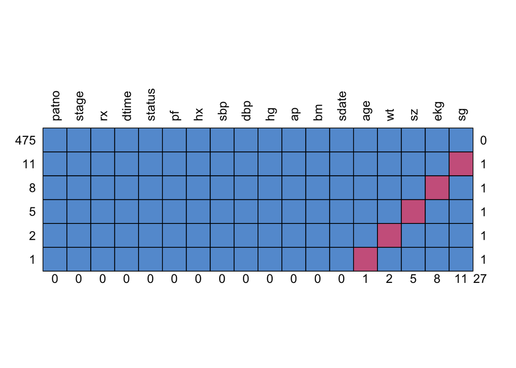

This tells us that 475 patients have complete data (blue indicates no missing values). 11 patients are missing `sg` measurements (red indicates missingness) and so on. No patients are missing multiple measurements.

`naclus` and `naplot` also summarize info on data missingness. See the `naplot()` documentation for more info.

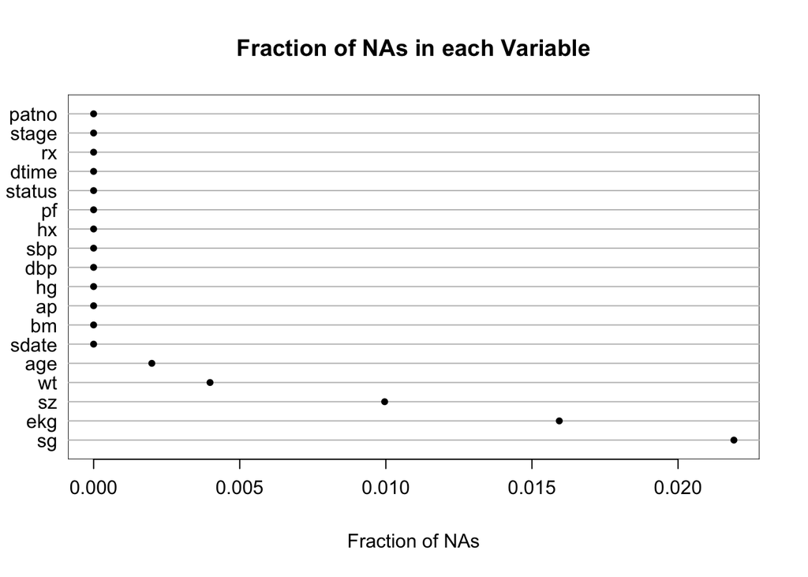

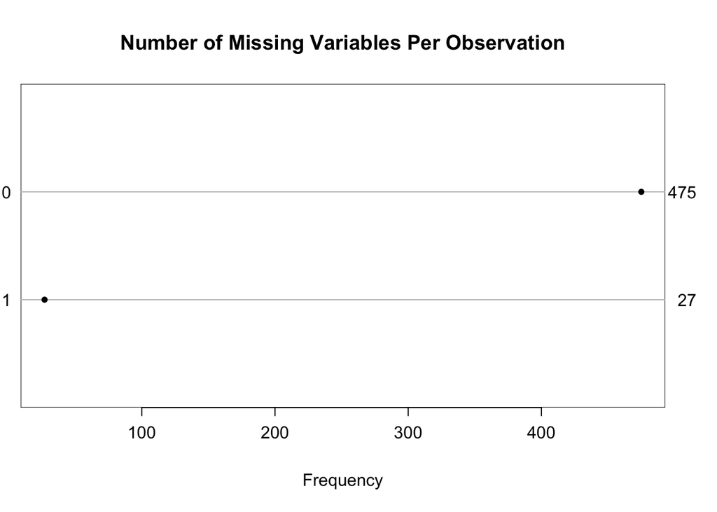

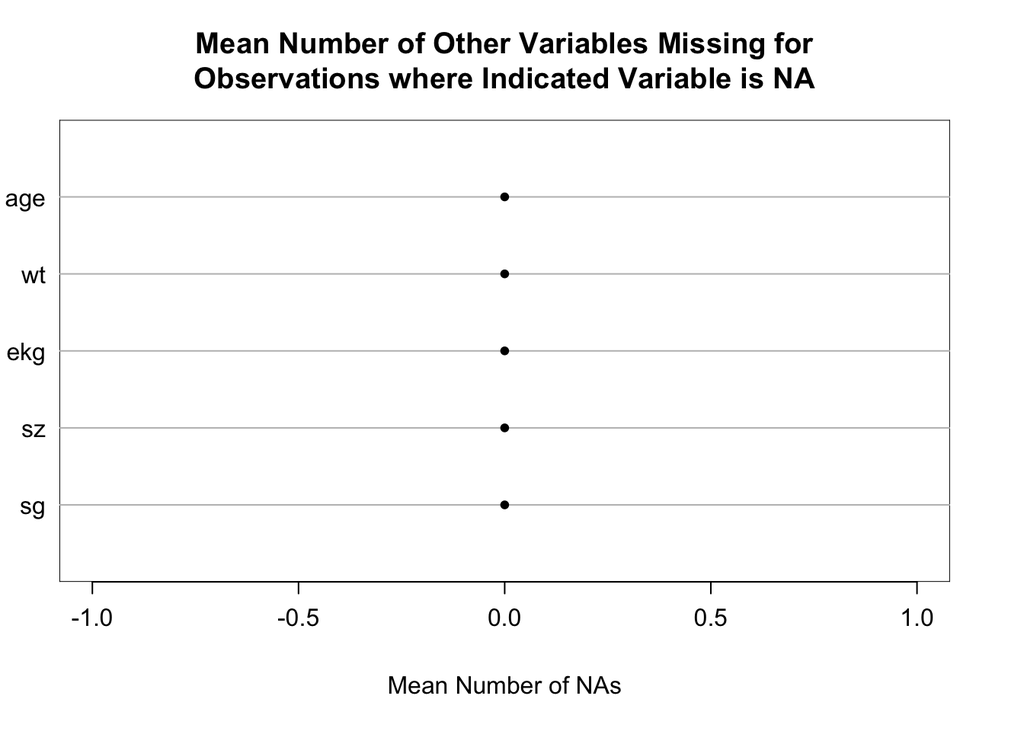

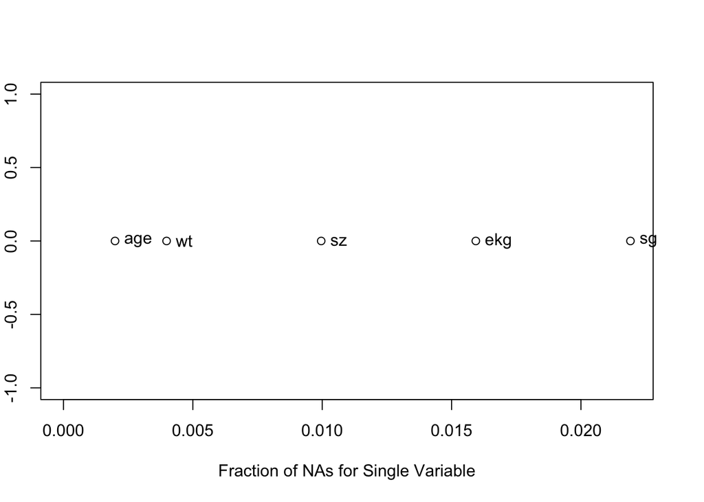

```r
na.patterns <- naclus(prostate)
naplot(na.patterns)
```

From these plots, we can see `age`, `wt`, `sz`, `ekg`, and `sg` all have missing values. We can also use decision trees to identify which types of patients were likely to have `sg` missing. This builds a model to predict which patients will be missing `sg` based on other patient characteristics. Note the formula syntax in the `rpart` call.

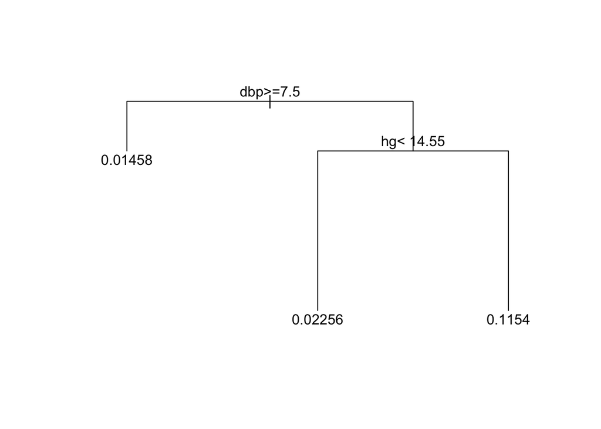

```r
who.na <- rpart(is.na(sg) ~ stage + rx + pf + hx + sbp + dbp +
                  hg + ap + bm, data = prostate, minbucket=15)
plot(who.na, margin = .1)
text(who.na)
```

It looks like `dbp` and `hg` are predictors of `sg` missingness. Now would be a good time to consult the clinician to ask why `dbp` and `hg` are predictive of missing `sg`.

It’s also good to know which variables are missing simultaneously from patients. The code below demonstrates this function

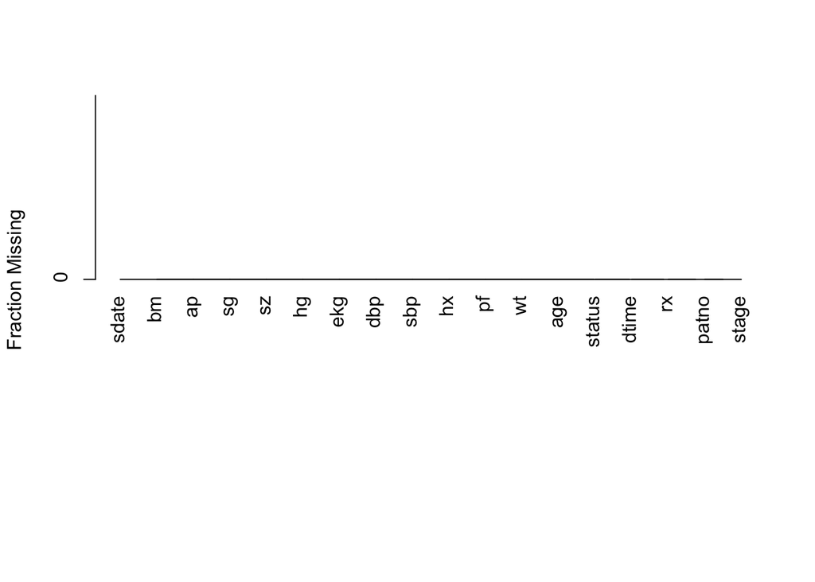

```r
plot(na.patterns)
```

In this case, no patients are missing multiple values so the plot looks empty. If more data was missing, the plot would show a clustering map that groups variables missing together most often. This plot can help us identify which variables may be dependent on each other (they may be measured at the same time). The empty plot indicates there isn’t a systematic issue with missing data. To see more examples with `plot(na.patterns)`, refer to Frank Harrell’s [Regression Modeling Strategies (RMS)](http://hbiostat.org/doc/rms.pdf) Chapter 12.4 for a case study on missing data. You’ll see a proper clustering example there.

After we’ve characterized missing data patterns, it’s time to decide how to tackle our missing data.

Harrell proposes a general rule of thumb when deciding how to approach missing data:

| Amount Missing | What to do |
| --- | --- |
| Less than 3% | Median imputation or case-wise deletion |
| More than 3% | MICE with max(5, 100x) imputations |
| Multiple predictors frequently missing | Sensitivity analysis with more imputations |

Median imputation is where we compute the median value for a variable, and replace all missing values with this median. Case-wise deletion means exlcuding patients with any missing values from analysis. Multiple Imputation By Chained Equation (MICE) is an algorithm that tries to predict missing data values. If a sensitivity analysis is needed, consult a statistician.

MICE has several assumptions that must be met for the algorithm to work properly. Using MICE requires two key decisions:

1. Is it plausible to assume our missing data is MAR? If we can’t assume MAR, time to find a statistician.
2. Assuming MAR, how will we model our missing data? What variables should we use to guess missing values?

Decision 1) ultimately comes down to whether we think there are unmeasured variables that **significantly** correlate with missingness. Unmeasured variables that are only slightly correlated with missingness should not prevent us from assuming MAR. We can also gather additional information outside of our survival analysis variables to build the MICE model. For example, we may not be interested in analyzing the effect of hospital location on survival, but which hospital the patient is from may determine if they have missing data. We can include this variable in our imputation model if it will help predict missingness even though we don’t plan to analyze the effect of hospital on survival. See section 6.2 in Stef van Burren’s [Flexible Imputation of Missing Data (FIMD)](https://stefvanbuuren.name/fimd/sec-whenignorable.html) for more details on deciding about MAR assumptions.

For decision 2), we can model missing data using MICE. We tell MICE which variables affect missingness, and then MICE uses these variables to generate a dataset with predicted values for missing data. Each predicted value has a random error component. To properly use imputation, we generate several datasets with MICE, analyze each dataset separately, and then average our results across datasets. Using multiple datasets retains the uncertainty from data being missing.

To use MICE, we need to specify our imputation model: which variables to include, what imputation method to use, and what order we will impute variables. MICE chooses robust defaults for all of these decisions. Predictive Mean Matching `pmm` is the default imputation method. When we pass `mice` a dataframe it will use all variables in the dataframe for the imputation model. If there are more than 20-30 variables in the imputation model, MICE will slow down and may not run. In this case, we can tell MICE to only use some variables. Make sure to include all variables that you’ll be analyzing (anything that is going in the Cox regression) and any variables that you suspect play a significant role in missingness.

See FIMD [section 6.3](https://stefvanbuuren.name/fimd/sec-modelform.html) for how to set which variables to include and more info on choosing variables.

Now let’s actually impute our missing data with MICE!

```r
impute_transform <- prostate %>%
  select(-patno, sdate) %>%
  mice(m = 5, method = 'pmm')
impute_fit <- fit.mult.impute(Surv(dtime, status) ~ rx + stage + rcs(age, 3),
                              cph, impute_transform, data = prostate)
```

After mice has run, `fit.mult.impute()` will build a model for each imputed dataset and average the models for us. The first argument is the regression formula you desire - don’t worry about the formula above, this will be explained in more detail later. `cph` is the type of regression model you want to use. `impute_transform` is the imputation object `mice` created for us.

Missing data can be a complex and important topic when modeling survival data. For more info, check out RMS Chapter 3 or van Burren’s FIMD (both referenced above). Because so few values are missing, we’ll opt for casewise completion for the rest of this tutorial.

```r
prostate <- prostate %>%
  drop_na()
```

## Model Fitting

With our data clean, we can move on to modeling. Cox Proportional Hazards (PH) regression is one of the most popular forms of survival analysis because we can analyze many variables at once with assumptions that are often reasonable for clinical practice. If you’re not familiar with Generalized Linear Models (GLMs), it’s helpful to think of Cox regression as a special form of linear regression. Unlike linear regression, the response variable $Y$ in Cox regression is censored survival outcome and the explanatory variable $\beta$’s are log hazard ratios.

The R packages `survival` and `rms` provide Cox regression functionality. In `survival`, users call `coxph()` while `cph()` is used in `rms`. We’ll focus on `cph()` because both work similarly and `cph` adds some extra functionality.

Before we can start modeling, we need to tell `rms` how the data is formatted.

```r
ddist <- datadist(prostate)
options(datadist="ddist")
```

We’re trying to evaluate effect of estrogen therapy `rx` on survival. Because patients were randomized to treatment or no treatment, we just need to include treatment in our Cox model to estimate the effect of estrogen therapy at different doses.

```r
rx.fit <- cph(Surv(dtime, status) ~ rx, data = prostate, x=T, y=T)
rx.fit
```

```
## Cox Proportional Hazards Model
##
##  cph(formula = Surv(dtime, status) ~ rx, data = prostate, x = T,
##      y = T)
##
##                       Model Tests       Discrimination
##                                            Indexes
##  Obs        475    LR chi2      8.85    R2       0.018
##  Events     338    d.f.            3    Dxy      0.058
##  Center -0.0769    Pr(> chi2) 0.0314    g        0.153
##                    Score chi2   8.32    gr       1.165
##                    Pr(> chi2) 0.0399
##
##                     Coef    S.E.   Wald Z Pr(>|Z|)
##  rx=0.2 mg estrogen  0.0311 0.1491  0.21  0.8347
##  rx=1.0 mg estrogen -0.3705 0.1618 -2.29  0.0220
##  rx=5.0 mg estrogen  0.0259 0.1491  0.17  0.8619
##
```

`cph` uses the formula notation to specify regression models. In formula notation, the response variable (usually denoted `Y`) is placed on the left hand side of the `~` and explanatory variables go on the right hand side (usually denoted `x1+x2+...`).

Our response variable `Y` is censored survival time outcomes, represented by `Surv(dtime, status)`. `Surv` uses time to event (`dtime`) and the outcome (`status`) to convert this info into a format readable by `R`. On the right hand side we’ve included `rx` as our explanatory variable.

Printing `fit` shows the log(Hazard Ratio) under `Coef` and p-value for each explanatory variable. `rx` shows up multiple times because it is a factor with multiple levels. Each coefficent for `rx` is for that dose compared against control (`placebo`). The arguments `x=T, y=T` tells `R` to store the dataset for plotting explanatory variable relationships.

We can plot the results from our model to visualize the hazard ratios

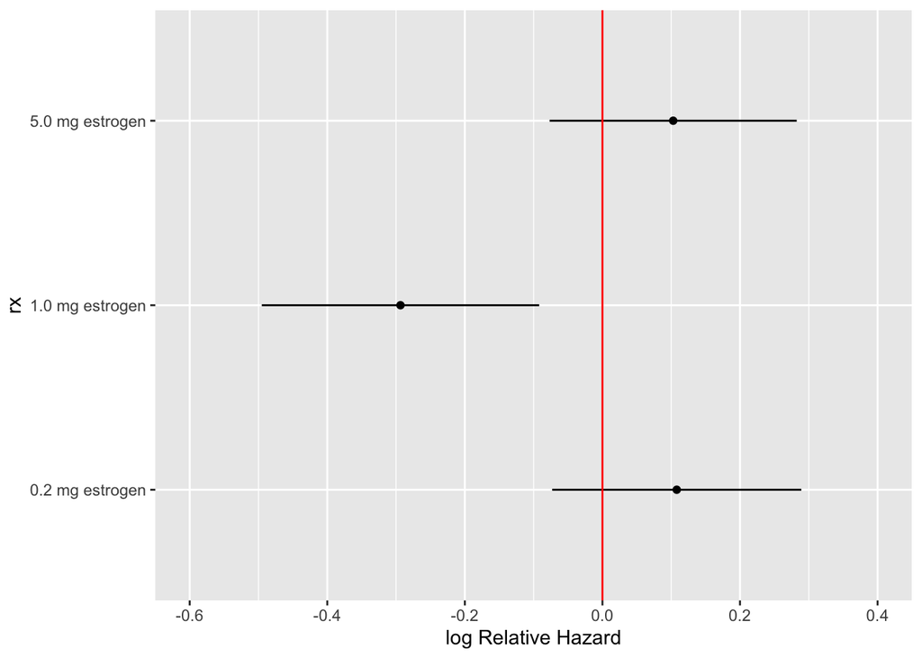

```r
ggplot(Predict(rx.fit, rx = c("0.2 mg estrogen", "1.0 mg estrogen", "5.0 mg estrogen"))) +
  geom_hline(aes(yintercept = 0), color = "red")
```

Remember that log(HR) < 0 indicates improved survival and log(HR) > 0 means worse survival.

It’s important to consider the uncertainty surrounding the effects estimates when deciding if a treatment works. A small p-value and decently large treatment effect suggests that 1.0 mg estrogen improves treatment survival. Large p-values and smaller effects estimates mean we don’t have enough evidence to claim 0.2 mg or 5.0 mg estrogen actually cause harm. This lack of evidence shouldn’t rule out the idea that 0.2 mg or 5.0 mg of estrogen can cause harm though - absence of evidence isn’t evidence of absence. It just means we can’t be certain either way and more data is needed. Although we are not doctors, some hypothesize there is an estrogen dosage “sweet spot” that causes 1.0 mg estrogen to improve survival. The idea is that too little estrogen (0.2 mg) isn’t strong enough to treat the cancer, while too much estrogen (5.0 mg) increases the risk of cardiovascular disease. Although this may be true, our results above indicate we’d need more evidence to make these conclusions.

Finally, results are typically presented as HR in papers, instead of log(HR). So let’s reformat the model coefficients to evaluate the effect of the treatments on change in hazard.

```r
exp(rx.fit$coefficients)
```

```
## rx=0.2 mg estrogen rx=1.0 mg estrogen rx=5.0 mg estrogen
##          1.0316081          0.6903886          1.0262891
```

Remember that HR < 1 indicates improved survival and HR > 1 means worse survival.

Given the treatment effect and significance above for 1.0 mg of estrogen, the results indicate 1.0 mg of estrogen cause a 0.3096114 reduction in hazard.Other doses of estrogen actually had small increases in effect on risk of death in the study population, but those effects were not conclusively proven to be different than treatment with placebo.

### Covariate Adjustment

Because RCTs randomize patients to treatment or an alternative (placebo or other intervention), simply estimating the treatment’s hazard ratio is enough to determine treatment effect because the randomization deals with confounding. This is called an unadjusted analysis because we didn’t adjust for any factors.

Although unadjusted analyses are acceptable for RCTs, there are benefits to adjusted analyses. Adjusting for strong prognostic factors in RCTs can increase power and improve effects estimates ([1](http://www.sciencedirect.com/science/article/pii/S0895435616001190)), ([2](https://lesslikely.com/statistics/equal-covariates/)), and ([3](https://discourse.datamethods.org/t/reference-collection-to-push-back-against-common-statistical-myths/1787)). To adjust for other variables, we add them as explanatory variables to our Cox model.

In observational studies, it’s critical to adjust for confounding variables because there is no randomization to control confounding and covariate imbalance. Observational studies usually adjust for more variables than RCTs because without randomization there are infinitely many variables that can confound a study. Researchers worry about lurking variables which are variables that confound the results but don’t get adjusted for because we don’t know they exist. Uncertainty about lurking variables is why we should interpret observational studies with considerable doubt compared to RCTs.

`age` is often a strong prognostic factor, especially in oncology; the older we get, the harder it is to tolerate and recover from harsh treatments like chemotherapy. We can adjust for age by adding `age` to our regression

```r
fit <- cph(Surv(dtime, status) ~ rx + age, data = prostate, x=T, y=T)
fit
```

```
## Cox Proportional Hazards Model
##
##  cph(formula = Surv(dtime, status) ~ rx + age, data = prostate,
##      x = T, y = T)
##
##                      Model Tests       Discrimination
##                                           Indexes
##  Obs       475    LR chi2     22.98    R2       0.047
##  Events    338    d.f.            4    Dxy      0.155
##  Center 2.2451    Pr(> chi2) 0.0001    g        0.304
##                   Score chi2  21.28    gr       1.355
##                   Pr(> chi2) 0.0003
##
##                     Coef    S.E.   Wald Z Pr(>|Z|)
##  rx=0.2 mg estrogen  0.0317 0.1491  0.21  0.8318
##  rx=1.0 mg estrogen -0.3359 0.1620 -2.07  0.0382
##  rx=5.0 mg estrogen  0.0577 0.1493  0.39  0.6991
##  age                 0.0322 0.0089  3.61  0.0003
##
```

Age is treated as a continuous variable, with the assumption that age is linearly related to survival. With our data, this means that for every additional year patients hazard will increase by $1 - e^{0.0322} =$ -0.032724.

To visualize age’s relation to survival, we plot age vs hazard

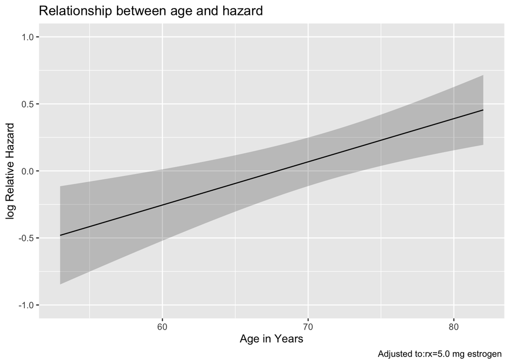

```r
ggplot(Predict(fit, age)) +
  labs(x = "Age in Years") +
  ggtitle("Relationship between age and hazard")
```

Remember that log(HR) > 0 means an increased risk of death. To plot hazard ratio instead, set `fun = exp` inside `Predict()`. The plot shows that patients over the age of 70 have an increased risk of death from prostate cancer.

### Relaxing the Linearity Assumption

Some continuous variables may not be linearly related to survival. When we have sufficient sample size, it’s optimal to treat these variables as nonlinear. This will improve power to detect a relationship and can improve effect estimation.

`rms` uses `rcs()` to model nonlinear variable with restricted cubic splines. We can use splines to treat age as if it’s nonlinearly related to survival.

```r
nonlinear.fit <- cph(Surv(dtime, status) ~ rx + rcs(age,5), data = prostate, x=T, y=T)
nonlinear.fit
```

```
## Cox Proportional Hazards Model
##
##  cph(formula = Surv(dtime, status) ~ rx + rcs(age, 5), data = prostate,
##      x = T, y = T)
##
##                       Model Tests       Discrimination
##                                            Indexes
##  Obs        475    LR chi2     33.29    R2       0.068
##  Events     338    d.f.            7    Dxy      0.180
##  Center -0.0378    Pr(> chi2) 0.0000    g        0.334
##                    Score chi2  38.86    gr       1.396
##                    Pr(> chi2) 0.0000
##
##                     Coef    S.E.   Wald Z Pr(>|Z|)
##  rx=0.2 mg estrogen  0.0513 0.1494  0.34  0.7313
##  rx=1.0 mg estrogen -0.3362 0.1623 -2.07  0.0383
##  rx=5.0 mg estrogen  0.0319 0.1540  0.21  0.8358
##  age                -0.0037 0.0281 -0.13  0.8961
##  age'                0.0203 0.0646  0.31  0.7538
##  age''               0.6582 1.4836  0.44  0.6573
##  age'''             -1.5080 3.3919 -0.44  0.6566
##
```

We must choose how many knots to use when modeling nonlinear variables. The number of knots determines how closely the regression fits the data. It’s recommended to use 3 to 5 knots for most problems: 3 for small datasets (~30 samples), 4 for medium datasets (~60 samples), and 5 for large datasets (~100 samples). These sample sizes are for uncensored data, so in most real world scenarios more samples will be needed when dealing with censored data. If these rules seem arbitrary to the reader and you’d like to choose the number of knots based on the data, Harrell recommends choosing the number of knots that maximizes model likelihood $\chi^2 - 2k$ where $k$ is the number of model parameters and $\chi^2$ is the $\chi^2$ statistic calculated from the model’s maximum likelihood estimate. This is `LR chi2` displayed in the `cph()` output under `Model Tests`. See RMS 2.4.6 for more information on restricted cubic splines and knot selection.

Multiple parameters are needed to model a nonlinear variable (`age` and `age'`, `age''`, and `age'''`). This makes interpretting results more complicated. Instead of just looking at the coefficient for `age`, we need to plot age vs hazard.

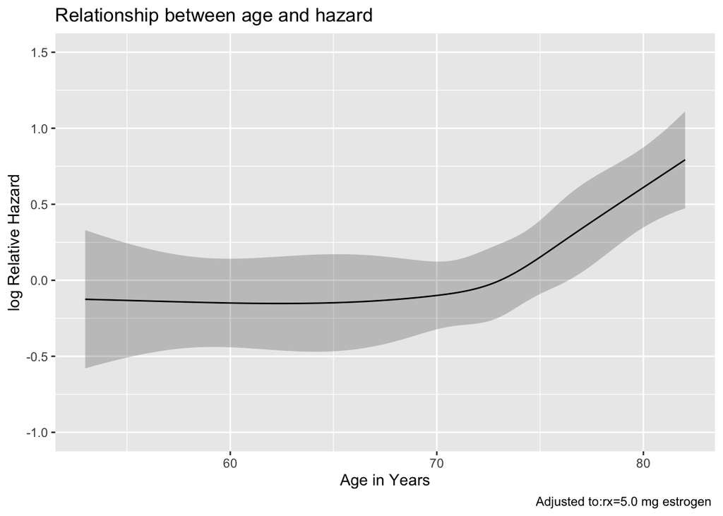

```r
ggplot(Predict(nonlinear.fit, age)) +
  labs(x = "Age in Years") +
  ggtitle("Relationship between age and hazard")
```

A one year increase in age no longer has a simple effect on survival. It seems patients younger than 70 are all at a relatively equal lower probability of death from prostate cancer. After about 70 years of age, patients begin to experience increasing risk of death. P-values are also not as straightforward to interpret. Because age can have a non-monotonic relationship with survival, we need a p-value to test if the nonlinear age function composed of several variables is associated with survival. Do not try to interpret the individual p-values for the age parameters (`age` and `age'` etc).

Using a chunk ANOVA test, we can compute p-values testing whether each predictor is associated with survival.

```r
anova(nonlinear.fit)
```

```
##                 Wald Statistics          Response: Surv(dtime, status)
##
##  Factor     Chi-Square d.f. P
##  rx          7.18      3    0.0665
##  age        28.00      4    <.0001
##   Nonlinear 11.10      3    0.0112
##  TOTAL      36.86      7    <.0001
```

Even if adjustment variables appear “nonsignificant” (p > .05), don’t remove them from the model! Adjusting for variables with p > .05 still improves our estimates. Removing “insignificant” variables would also violate p-value inference rules. It’s best to prespecify the adjustment variables included in the model before analyzing data and then reporting the full model with all variables.

See Tomas’ Cross Validated [post](https://stats.stackexchange.com/questions/405832/interpretting-cox-regression-anova) for more details on interpretting the ANOVA.

### Subgroup Analysis Using Interactions

Precision medicine emphasizes treatment effect heterogeneity: due to differing patient characteristics, a drug that may work for one person won’t necessarily work for another. These concerns often drive researchers to investigate subgroup differences. Subgroups can be derived from any stratifying feature; male/female or mutation/no mutation are common stratifying factors.

To investigate subgroup differences, it’s common for researchers to divide patients into separate cohorts based on the stratifying factor, perform a separate analysis for each cohort, and then compare findings between cohorts. For a survival analysis, this could mean dividing patients into male and female cohorts, fitting Cox regressions for each cohort, and then comparing the hazard ratios and p-values between males and females. If any of the hazard ratios or p-values differ, investigators will often claim effect heterogeneity between sexes.

Unfortunately there are problems with this analysis. First, splitting patients into separate cohorts reduces sample size, making it more difficult to detect effects. This is especially problematic when the subgroups are imbalanced. If there were 4x more males than females, it will be easier to find a “significant” hazard ratio for the males than the females because there are more samples. Finding a significant hazard ratio in one cohort but not the other doesn’t necessarily mean the effect sizes are different; a smaller sample size in the female cohort may be making the p-value larger even though the hazard ratios are the same.

Second, subgroup analysis doesn’t provide any means to test or estimate the effect difference between cohorts. Although males may have a different hazard ratio than females, how can we be sure this difference isn’t due to sampling error? There also isn’t an easy way to build a confidence interval for the hazard ratio difference between sexes. Without a p-value or confidence interval, it’s hard to be confident that the male/female difference we’re observing is truly real.

To remedy these problems, we should use interaction terms in our regression formulas. An interaction term models how the hazard ratio of one variable changes for different values of another variable. An interaction term between treatment and male/female could be used to assess whether female patients experience a better response than male patients. We can also compute p-values and confidence intervals for interaction terms, helping us understand the uncertainty around the treatment effect heterogeneity.

Interactions are easy to include in `R` formulas

```r
interact.fit <- cph(Surv(dtime, status) ~ rx*bm, data = prostate, x=T, y=T)
interact.fit
```

```
## Cox Proportional Hazards Model
##
##  cph(formula = Surv(dtime, status) ~ rx * bm, data = prostate,
##      x = T, y = T)
##
##                      Model Tests       Discrimination
##                                           Indexes
##  Obs       475    LR chi2     35.77    R2       0.073
##  Events    338    d.f.            7    Dxy      0.143
##  Center 0.0572    Pr(> chi2) 0.0000    g        0.315
##                   Score chi2  45.31    gr       1.370
##                   Pr(> chi2) 0.0000
##
##                            Coef    S.E.   Wald Z Pr(>|Z|)
##  rx=0.2 mg estrogen         0.0454 0.1639  0.28  0.7817
##  rx=1.0 mg estrogen        -0.3707 0.1836 -2.02  0.0435
##  rx=5.0 mg estrogen         0.1112 0.1662  0.67  0.5034
##  bm=1                       1.0804 0.2786  3.88  0.0001
##  rx=0.2 mg estrogen * bm=1 -0.0428 0.3954 -0.11  0.9138
##  rx=1.0 mg estrogen * bm=1 -0.4699 0.3946 -1.19  0.2337
##  rx=5.0 mg estrogen * bm=1 -0.8701 0.3793 -2.29  0.0218
##
```

Above we’ve included an interaction term between treatment `rx` and bone metastasis `bm`, useful if we suspect treatment efficacy differs between patients with and without bone metastases. In `R`, `x1*x2` specifies an interaction term between `x1` and `x2` and will also include `x1` and `x2` as separate terms. It’s equivalent to writing `x1 + x2 + x1*x2`. We can look at the hazard ratios and p-values to weigh the evidence for treatment differences among bone metastases groups. 0.2 mg and 1.0 mg of estrogen have large p-values, suggesting there may be no difference in treatment effect between patients with/without bone metastasis. Although this seems logical from the p-values, be cautious interpretting interactions; most interactions are underpowered because sample sizes are often halved (or worse) due to the nature of comparing two separate, smaller subgroups. Interactions often require [16x the number of patients](https://www.ncbi.nlm.nih.gov/pmc/articles/PMC3193873/) to achieve the same power as normal variables, so unless the analysis was powered for an interaction, interpret these results carefully.

Meanwhile 5.0 mg estrogen’s small p-value suggests evidence for treatment effect heterogeneity. `bm` is an indicator variable with a status of 0 (no metastasis) or 1 (bone metastasis). We interpret the interaction as follows: if `bm = 1`, the coefficient would be -.8701, a rather large hazard reduction. If `bm = 0`, the coefficient is 0, because $0 * -.8701 = 0$. It seems patients with bone metastases show a much better response to 5.0 mg of estrogen than patients without bone metastases.

`anova()` will also tell us the overall effect of the interaction

```r
anova(interact.fit)
```

```
##                 Wald Statistics          Response: Surv(dtime, status)
##
##  Factor                                 Chi-Square d.f. P
##  rx  (Factor+Higher Order Factors)      18.18      6    0.0058
##   All Interactions                       6.94      3    0.0740
##  bm  (Factor+Higher Order Factors)      32.85      4    <.0001
##   All Interactions                       6.94      3    0.0740
##  rx * bm  (Factor+Higher Order Factors)  6.94      3    0.0740
##  TOTAL                                  41.50      7    <.0001
```

Make sure to check the overall interaction’s p-value with anova before looking at individual level p-values. If the overall interaction isn’t meaningfully small, the individual terms should be considered weak evidence. If at least one of your interaction terms includes a nonlinear continuous variable, make sure to use ANOVA to compute p-values - don’t look at the individual p-values!

A final note on interpretting interaction terms. If there is enough evidence to believe the interaction term is non-null, to calculate the final hazard ratio for a variable, we must add all log hazard ratios that relate to that variable.

Seeing the Cox regression formula helps us understand what coefficients we need to add. For our model with `rx`, `bm` and their interaction, the regression looks like

$$\lambda(t) = \lambda_0(t)\text{exp}({\beta_1x_1 + \beta_2x_2+\beta_3x_3 + \beta_4x_4 + \beta_5x_1x_4 + \beta_6x_2x_4 + \beta_7x_3x_4})$$

where $x_1$ indicates 0.2 mg estrogen, $x_2$ indicates 1.0 mg estrogen, $x_3$ indicates 5.0 mg estrogen, and $x_4$ indicates bone metastasis. $\beta_i$ is the log hazard ratio for the $i$th variable. $\beta_5$, $\beta_6$, and $\beta_7$ represent the interaction term coefficients. To compute the full hazard for bone metastasis ($x_4 = 1$) patients treated with 5.0 mg estrogen ($x_3 = 1$ and $x_1, x_2 = 0$) we’d compute

$$\text{exp}({\beta_3 + \beta_4 + \beta_7}) = \text{HR}\\
\text{exp}({0.1112 + 1.0804 -0.8701}) = 1.379195$$

This is confirmed when we plot the hazard for bone metastasis for patients treated with 5.0 mg estrogen.

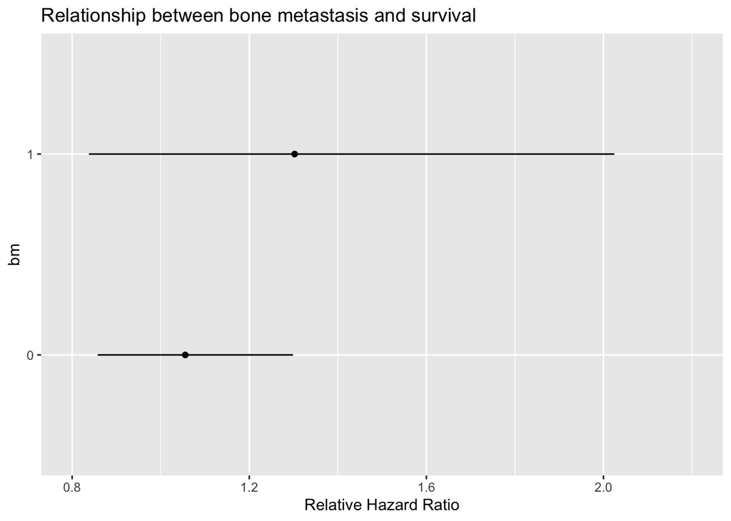

```r
ggplot(Predict(interact.fit, rx=c("5.0 mg estrogen"), bm, fun = exp)) +
  labs(y = "Relative Hazard Ratio") +
  ggtitle("Relationship between bone metastasis and survival")
```

The Analysis Factor provides more information on interpretting interaction terms [here](https://www.theanalysisfactor.com/interpreting-interactions-in-regression/).

### Checking Model Assumptions

Once we’ve fitted our model, we need to check our assumptions before accepting our results. The important assumption in Cox regression is the Proportional Hazards (PH) assumption. This means that the hazard ratio for any variables in the model stays constant over time.

We can test these assumptions with `cox.zph()`

```r
cox.zph(fit)
```

```
##                        rho  chisq       p
## rx=0.2 mg estrogen  0.0180  0.109 0.74130
## rx=1.0 mg estrogen -0.0711  1.726 0.18893
## rx=5.0 mg estrogen -0.0253  0.219 0.63962
## age                -0.1447  9.121 0.00253
## GLOBAL                  NA 11.488 0.02159
```

This code tests the proportional hazards assumption for individual variables and the overall model. Above we tested our first model that included treatment and linear age. There’s evidence that the hazard ratio for age changes over time, and this is problematic for our model (GLOBAL p=.02159). A small p-value suggests the PH assumption is broken. When continuous variables break the PH assumption, modeling them as nonlinear variables can correct the PH problems.

```r
cox.zph(nonlinear.fit)
```

```
##                         rho  chisq     p
## rx=0.2 mg estrogen  0.02245 0.1718 0.679
## rx=1.0 mg estrogen -0.07035 1.7114 0.191
## rx=5.0 mg estrogen -0.02848 0.2864 0.593
## age                -0.00765 0.0197 0.888
## age'               -0.03772 0.4812 0.488
## age''               0.02373 0.1928 0.661
## age'''             -0.01059 0.0382 0.845
## GLOBAL                   NA 9.7277 0.205
```

The GLOBAL p-value now suggests the overall PH assumption is satisfied.

When categorical variables break the PH assumption, stratification can fix these issues. Stratification will usually eliminate PH problems at the loss of parameter estimation for that variable; you’ll no longer have a hazard ratio for the stratification variable. Pretend `bm` was having PH problems, to stratify by `bm` we’d code

```r
cph(Surv(dtime, status) ~ rx + strat(bm), data = prostate, x=T, y=T)
```

```
## Cox Proportional Hazards Model
##
##  cph(formula = Surv(dtime, status) ~ rx + strat(bm), data = prostate,
##      x = T, y = T)
##
##         Status
##  Stratum No Event Event
##     bm=0      127   271
##     bm=1       10    67
##
##                       Model Tests       Discrimination
##                                            Indexes
##  Obs        475    LR chi2     11.11    R2       0.023
##  Events     338    d.f.            3    Dxy      0.052
##  Center -0.1198    Pr(> chi2) 0.0111    g        0.187
##                    Score chi2  10.46    gr       1.205
##                    Pr(> chi2) 0.0150
##
##                     Coef    S.E.   Wald Z Pr(>|Z|)
##  rx=0.2 mg estrogen  0.0321 0.1492  0.21  0.8299
##  rx=1.0 mg estrogen -0.4446 0.1634 -2.72  0.0065
##  rx=5.0 mg estrogen -0.0716 0.1520 -0.47  0.6376
##
```

Stratification can also be used to adjust for variables whose hazard ratio isn’t of interest but we’d still like to adjust for differences caused by this variable. Multicenter clinical trials will often stratify by hospital in their analysis as investigators want to adjust for care differences attributed to each hospital but usually aren’t interested in the actual hazard ratio for each hosptial.

If you’re still having trouble with PH assumptions after trying nonlinear modeling and stratification, Cox may not be appropriate. Accelerated time failure (AFT) models may be more appropriate for your data. See RMS Chapter 18 for information on AFT models.

## Conclusion

During this tutorial we’ve covered data preparation, missing data, and survival analysis with Cox regression. Our explanations for each topic are just the tip of the iceberg.

Missing data is a complex topic with considerable research to support imputation methods. See [Flexible Imputation For Missing Data](https://stefvanbuuren.name/fimd/) by Stef van Burren for an indepth look at imputation. [Sterne et al](https://www.bmj.com/content/338/bmj.b2393) also have a good summary of imputation for the non-statistician.

Although we focused on effect estimation with the Cox model, regression modeling is also used for prediction. Frank Harrell’s [Regression Modeling Strategies](http://hbiostat.org/doc/rms.pdf) covers regression and its applications in much more depth.

Finally, Sashegyi and Ferry have a good explanation of hazard ratios and how to communicate their meaning with clinicians [here](https://www.ncbi.nlm.nih.gov/pmc/articles/PMC5388384/).